# Tema 3. Flujo de datos

### 1.1.3 Faceting

En el análisis de datos, a menudo no solo nos interesa estudiar la relación entre dos variables, sino también **cómo cambia esa relación entre distintos grupos** (por ejemplo, entre islas, sexos o especies). Representar todos los datos juntos puede ocultar patrones importantes.

El **faceting** es una técnica de `ggplot2` que permite **dividir un mismo gráfico en varios paneles**, de modo que cada panel muestra un subconjunto de los datos, manteniendo una estructura visual común. Esto facilita la **comparación directa entre grupos**.

#### 1.1.3.1 Gráfico base

Antes de aplicar faceting, es fundamental construir un **gráfico base** que represente correctamente la relación que queremos analizar. En este ejemplo, estudiaremos la relación entre la masa corporal y la longitud de la aleta de los pingüinos, diferenciando las especies mediante color.

```r
penguins_plot <- ggplot(
  data = penguins,
  aes(
    x = body_mass_g,
    y = flipper_length_mm,
    color = species
    ) ) +
  geom_point(na.rm = TRUE)

penguins_plot
```

[output not shown]

Este gráfico muestra **todos los individuos juntos**. Permite observar la tendencia general, pero no facilita la comparación entre grupos específicos como islas o sexos.

#### 1.1.3.2 Faceting por una variable categórica

Para analizar si la relación entre masa corporal y longitud de aleta varía según la isla, podemos dividir el gráfico en varios paneles, uno por cada isla. Esto se consigue con `facet_wrap()`.

```r
penguins_plot +
  facet_wrap(vars(island))
```

[figure not shown]

```r
penguins_plot +
  facet_wrap(~island)
```

[figure not shown]

Cada panel contiene únicamente los datos correspondientes a una isla, pero todos comparten los mismos ejes. Esto permite comparar visualmente las distribuciones y relaciones entre islas de forma clara y directa.

Este tipo de faceting es especialmente útil cuando se quiere estudiar **un único factor categórico**.

#### 1.1.3.3 Faceting estructurado: filas y columnas con `facet_grid()`

Cuando queremos estudiar simultáneamente **dos variables categóricas**, `facet_grid()` permite organizar los paneles en una rejilla definida por filas y columnas.

En el siguiente ejemplo, los datos se separan por especie (filas) e isla (columnas):

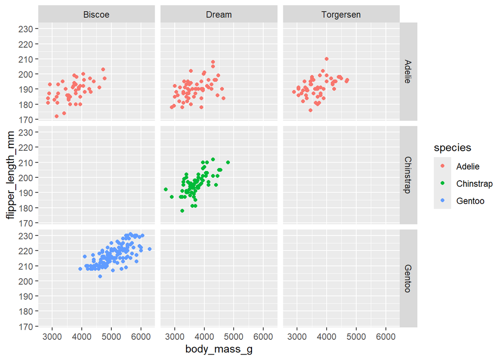

```r
penguins_plot +
  facet_grid(rows = vars(species),
             cols = vars(island))
```

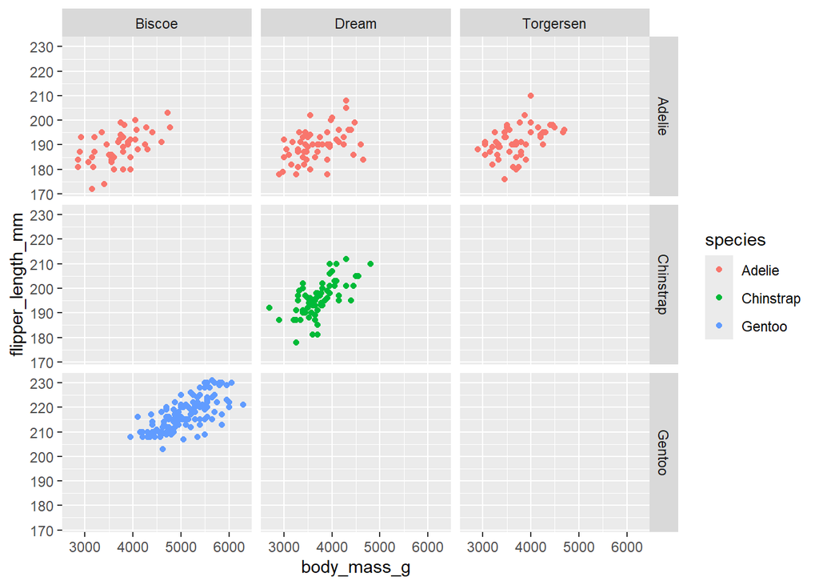

```r
penguins_plot +
  facet_grid(species ~ island)
```

#### 1.1.3.4 `facet_wrap()` frente a `facet_grid()`

Aunque ambas funciones crean múltiples paneles, tienen usos distintos:

- `facet_grid()` se utiliza cuando queremos **controlar explícitamente** la disposición en filas y columnas.
- `facet_wrap()` es más flexible y se adapta mejor cuando una variable categórica tiene muchos niveles.

  Por ejemplo, una representación más compacta por especie sería:

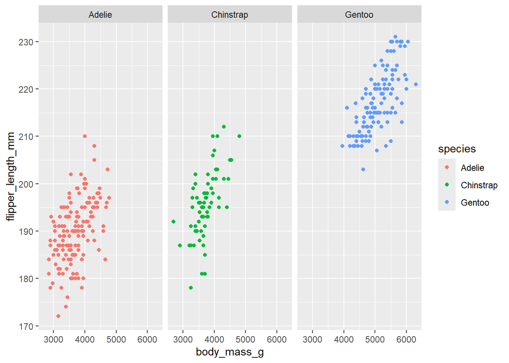

```r
# Facet wrap (organiza en rejilla)

penguins_plot +
  facet_wrap(facets = vars(species), ncol = 3)
```

#### 1.1.3.5 Comparación visual: sin faceting vs con faceting

Sin faceting, el gráfico muestra una visión global, pero dificulta responder preguntas como:

- ¿La relación entre masa corporal y longitud de aleta es igual en todas las islas?
- ¿Hay islas con mayor variabilidad?

El faceting no añade datos nuevos, pero **organiza la información de forma que estas comparaciones sean más evidentes**.

#### 1.1.3.6 Escalas fijas y escalas libres

Por defecto, todos los paneles utilizan la misma escala en los ejes, lo que facilita la comparación entre grupos.

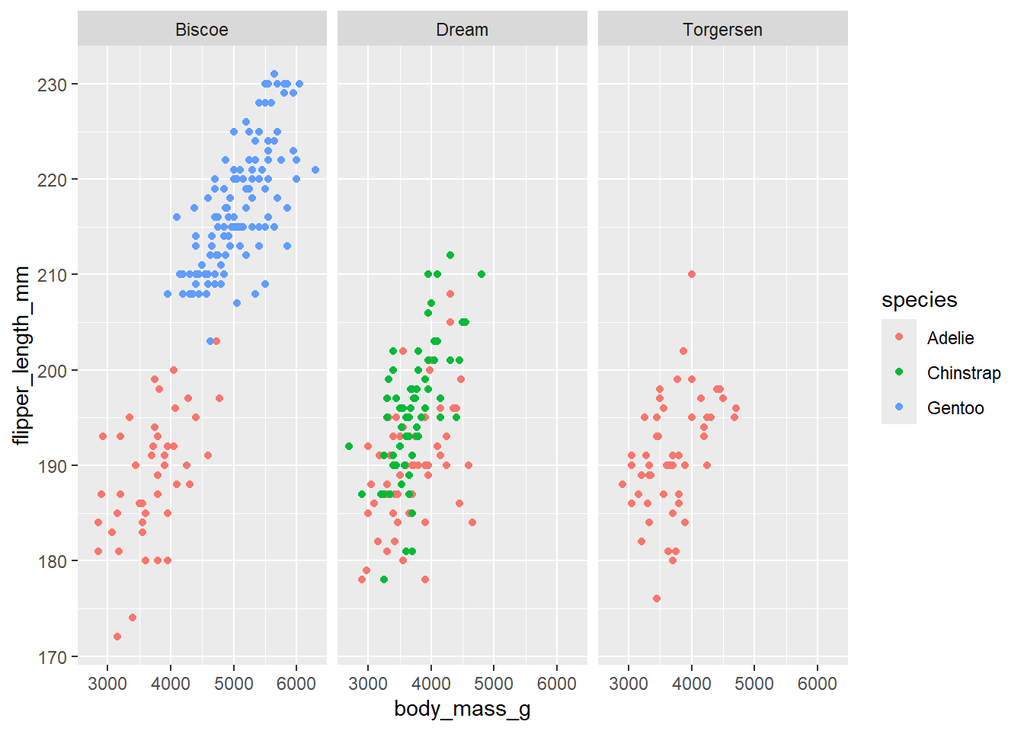

```r
penguins_plot +
  facet_wrap(vars(island))
```

Sin embargo, en algunos casos puede ser útil permitir que cada panel tenga su propia escala:

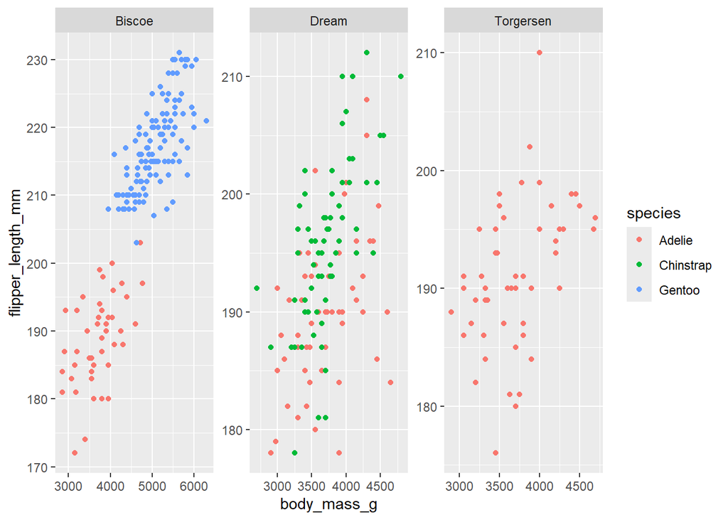

```r
penguins_plot +
  facet_wrap(vars(island), scales = "free")
```

- **Escalas fijas**: recomendadas cuando se quiere comparar valores entre grupos.
- **Escalas libres**: útiles para explorar la variabilidad interna de cada grupo, aunque dificultan la comparación directa.

#### 1.1.3.7 Idea clave

  > El faceting permite comparar grupos sin cambiar el diseño del gráfico.  
  > No crea gráficos diferentes, sino distintas “ventanas” de la misma visualización.

#### 1.1.3.8 📝 Ejercicio: faceting

Visualiza la relación entre masa corporal (body_mass_g) y longitud de aleta (flipper_length_mm) diferenciando por sexo y especie. Crea un gráfico de dispersión de *body_mass_g* vs *flipper_length_mm*, coloreando los puntos por species.

- Filas: sex
- Columnas: species

Observa cómo se distribuyen los datos según estas dos variables categóricas.

Preguntas:

- ¿Qué patrones diferenciales se observan entre machos y hembras para cada especie?
- ¿Qué ventaja tiene `facet_grid()` para comparar categorías cruzadas en filas y columnas?

Visualiza la relación entre longitud del pico (bill_length_mm) y profundidad del pico (bill_depth_mm) por isla.

- Crea un gráfico de dispersión de bill_length_mm vs bill_depth_mm, coloreando los puntos por species.

Aplica la faceta más adecuada para crear un panel por isla, con 2 columnas (ncol = 2).

- Analiza cómo varían las medidas del pico según la isla.

Preguntas:

- ¿Qué faceta es más adecuada cuando solo queremos facetear por una variable con varias categorías?
- ¿Qué información adicional se obtiene al comparar paneles lado a lado?

### 1.1.4 Posición

El parámetro *position* controla cómo se disponen elementos geométricos cuando hay superposiciones, especialmente en gráficos de barras con agrupaciones. Por defecto, `ggplot2` usa posición “stack” (apilado), donde las barras se apilan unas sobre otras mostrando el total por categoría.

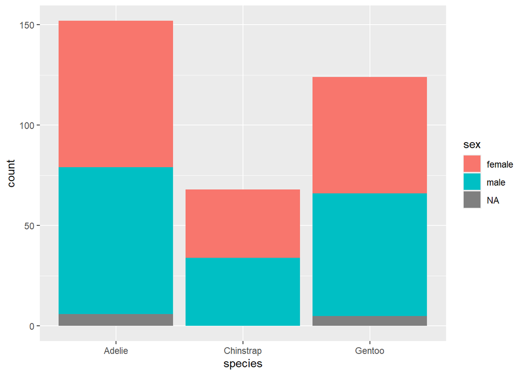

```r
# Por defecto: apilado (stack)
ggplot(data = penguins) +
  geom_bar(aes(x = species,
               fill = sex))
```

La posición “dodge” coloca las barras lado a lado, lo que facilita la comparación directa de los subgrupos dentro de cada categoría principal.

```r
ggplot(data = penguins) +
  geom_bar(aes(x = species, fill = sex),
           position = "dodge")
```

[figure not shown]

La posición “fill” también apila las barras, pero normaliza la altura al 100%, mostrando proporciones en lugar de conteos absolutos. Esto es útil para comparar la composición relativa de cada categoría.

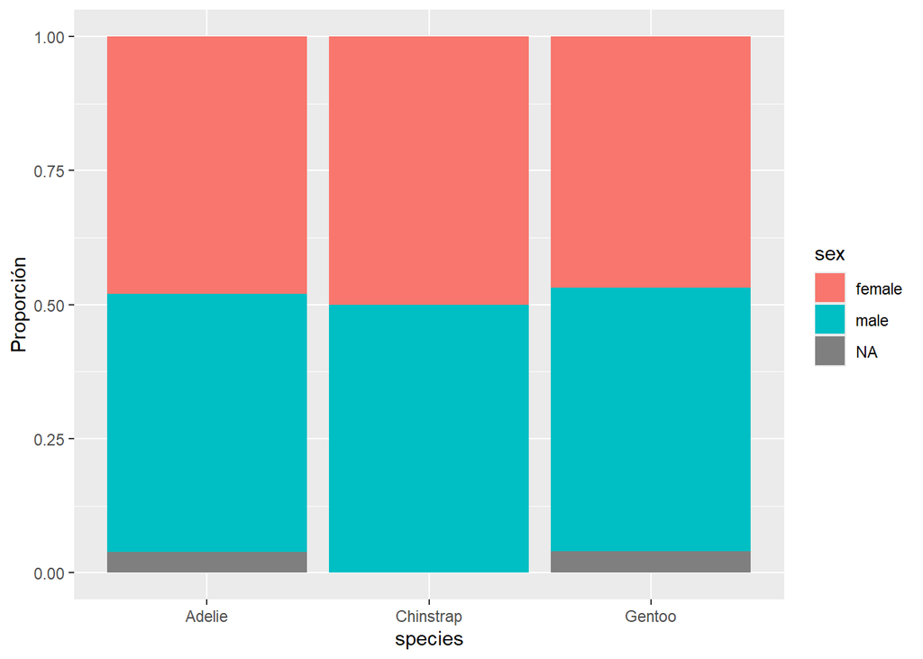

```r
# Proporciones (fill)
ggplot(data = penguins) +
  geom_bar(aes(x = species, fill = sex),
           position = "fill") +
  labs(y = "Proporción")
```

## 1.2 Visualización de datos numericos: univariante.

Para visualizar datos numericos en múltiples ocasiones estamos interesados en la **forma** (si está sesgado o es simétrico, si es unimodal, etc.), medidas de la **centralidad** de los datos (media, mediana, moda), o de **variabilidad** de lo datos (rango, desviación estandar, rango intercuartilico), así como en conocer **datos anómalos**.

Para ello vamos a aprender a hacer gráficos básicos con esta información. Empezamos por el **histograma**.

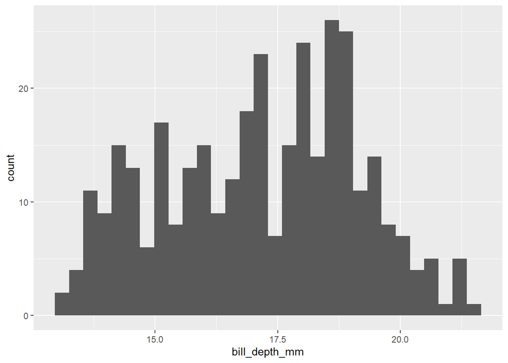

```r
ggplot(penguins,
  aes(bill_depth_mm)) +
  geom_histogram()
```

Este gráfico se debe mejorar, poniendo los ejes de una manera adecuada, etc.

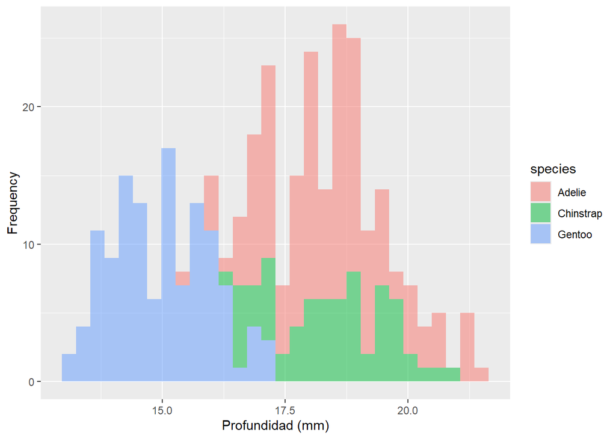

```r
ggplot(penguins,
  aes(bill_depth_mm,
      fill = species)) +
  geom_histogram(alpha = 0.5) +
   labs(
    x = "Profundidad (mm)",
    y = "Frequency"
  )
```

No es muy sencillo de comparar, por lo que podríamos usar las facetas.

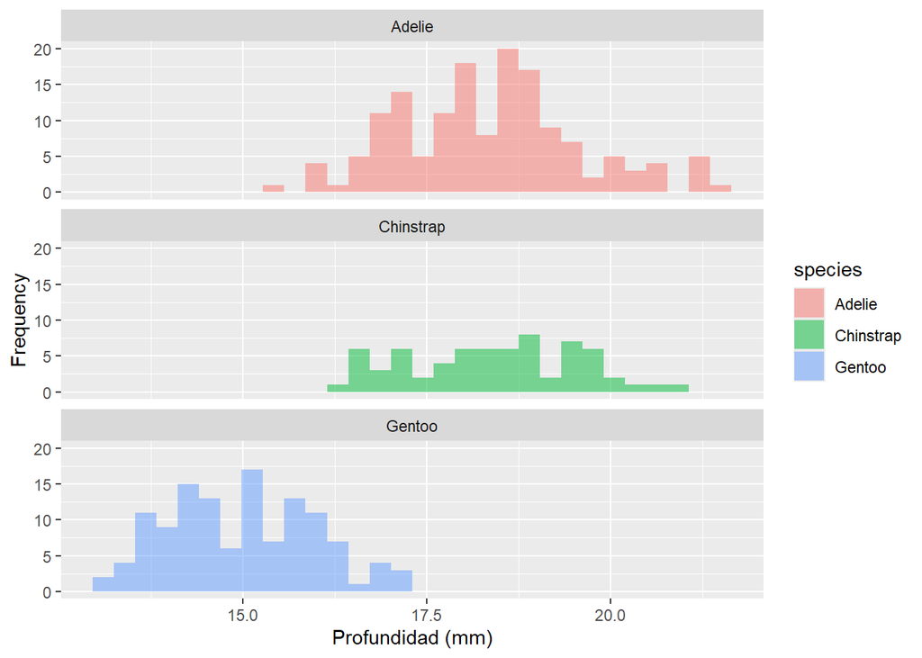

```r
ggplot(penguins,
  aes(bill_depth_mm,
      fill = species)) +
  geom_histogram(alpha = 0.5) +
   labs(
    x = "Profundidad (mm)",
    y = "Frequency"
  ) +
  facet_wrap(~ species, nrow = 3)
```

#### 1.2.0.1 📝 Ejercicio: trabajando con relaciones univariantes.

Por favor, repite el ejercicio anterior haciendo un gráfico de densiad con `geom_density` y un gráfico de cajas y bigotes con `geom_boxplot`.

#### 1.2.0.2 📝 Ejercicio: ¿cuáles son los principales tipos de gráficos univariantes y para qué sirven?

Busca todos los tipos de gráficos que hay, y analiza que tipo de respuesta nos dan. Debate en clase. Revisa esta web: https://r-graph-gallery.com/

### 1.2.1 Distribución de una variable continua

Para explorar cómo se distribuyen los valores de una variable continua, usamos principalmente dos tipos de gráficos:

**Histograma** (`geom_histogram()`): Divide el rango de valores en intervalos (bins) y muestra la frecuencia en cada intervalo:

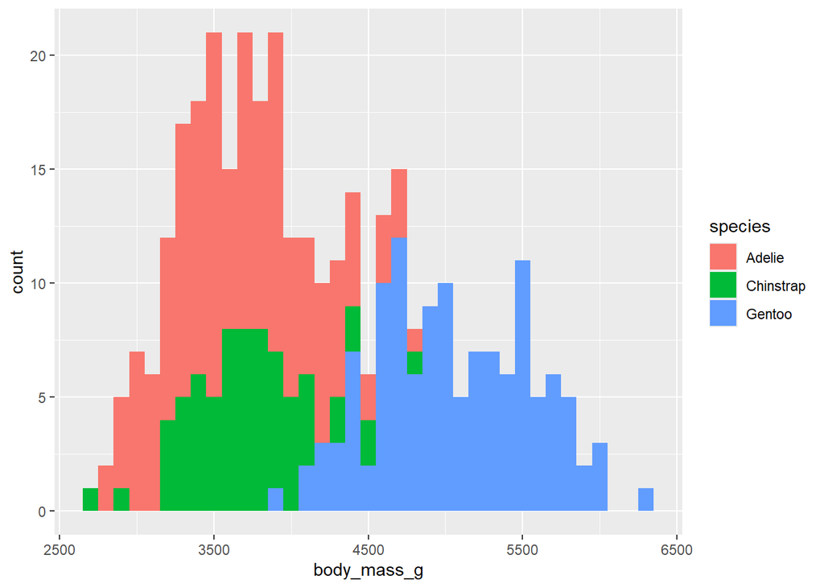

```r
# Histograma básico - muestra la distribución en intervalos
ggplot(penguins, aes(x = body_mass_g,
                     fill = species)) +
  geom_histogram(binwidth = 100)  # binwidth controla el ancho de cada intervalo
```

**Gráfico de densidad** (`geom_density()`): Muestra una estimación suavizada de la distribución continua:

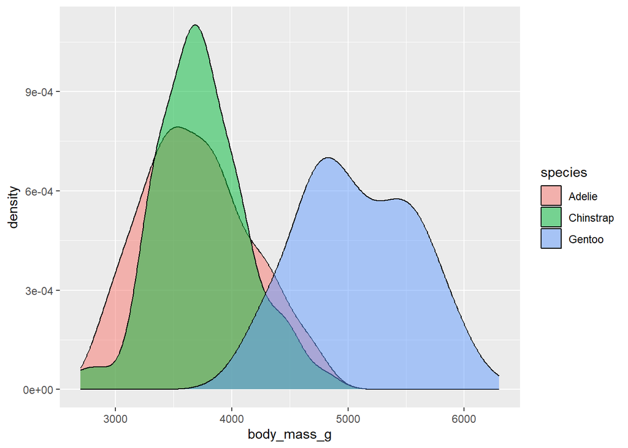

```r
# Gráfico de densidad - curva suavizada
ggplot(penguins, aes(x = body_mass_g,
                     fill = species) ) +
  geom_density(alpha = 0.5)
```

Comparación entre grupos: Cuando queremos comparar la distribución de una variable continua entre diferentes categorías podemos utilizar:

Diagrama de cajas (`geom_boxplot()`) -> Muestra estadísticos de resumen (mediana, cuartiles, valores atípicos):

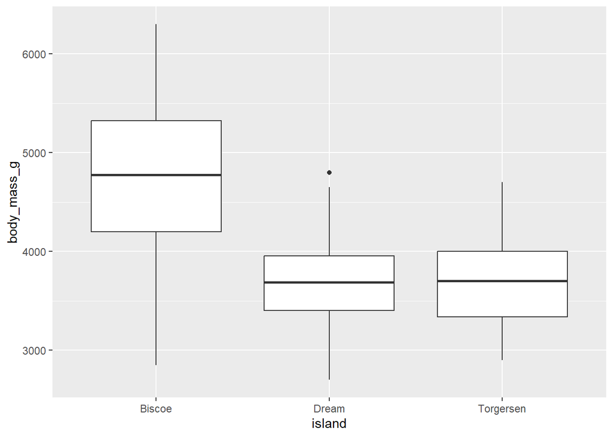

```r
# Boxplot comparando masa corporal entre especies
ggplot(penguins,
       aes(x = island, y = body_mass_g)) +
  geom_boxplot()
```

Gráfico de violín (`geom_violin()`) -> Combina las ventajas del boxplot con la visualización de la densidad:

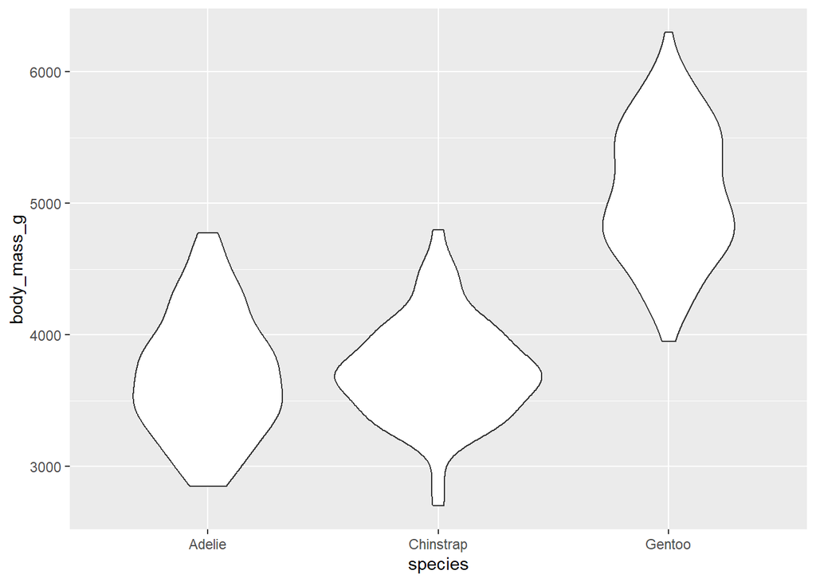

```r
# Gráfico de violín mostrando la forma completa de la distribución
ggplot(penguins,
       aes(x = species, y = body_mass_g)) +
  geom_violin()
```

### 1.2.2 Variables cuantitativas discretas

Estas variables solo pueden tomar valores enteros o contables específicos (no hay valores intermedios entre ellos). Aunque en penguins no hay ejemplos claros de variables discretas, podemos crear uno para ilustrar el concepto.

Ejemplo con datos discretos: Supongamos que tenemos datos sobre el número de crías por nido (variable discreta):

```r
# Creamos datos de ejemplo para variable discreta
datos_crias <- data.frame(
  nido = 1:50,
  crias = sample(1:5, 50,
                 replace = TRUE,
                 prob = c(0.1, 0.2, 0.4, 0.2, 0.1)) )
```

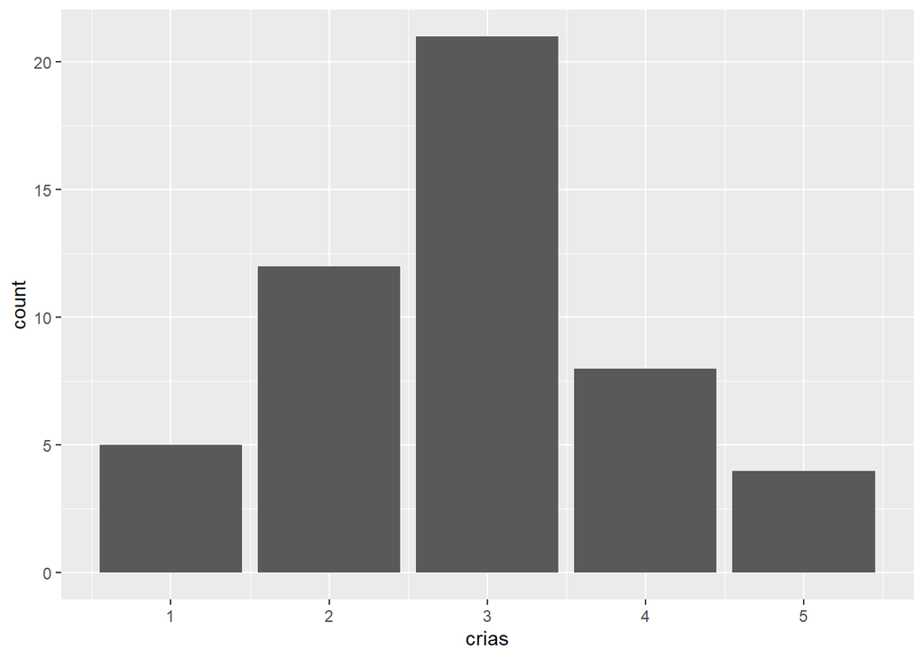

```r
# Opción 1: geom_bar() para conteos de valores discretos

ggplot(datos_crias,
       aes(x = crias)) +
  geom_bar(stat = "count")
```

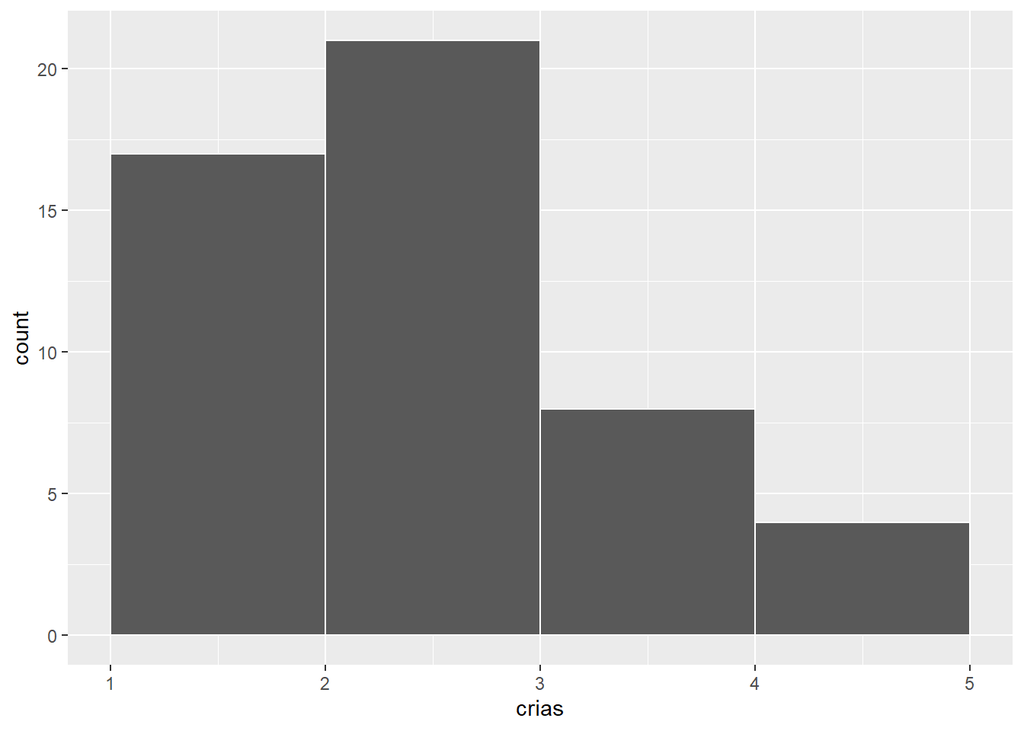

```r
# Opción 2: geom_histogram() con binwidth = 1 y límites alineados

ggplot(datos_crias,
        aes(x = crias)) +
        geom_histogram(binwidth = 1,
                       center = 0.5, color = "white")
```

### 1.2.3 Diferencias clave en el tratamiento gráfico

[output not shown]

#### 1.2.3.1 ¿Cómo elegir? Para variables continuas:

Histograma (`geom_histogram`): Cuando queremos ver la distribución en intervalos específicos

Densidad (`geom_density`): Cuando queremos una visión suavizada de la distribución

Boxplot (`geom_boxplot`): Para comparar estadísticos entre grupos

Violín (`geom_violin`): Para comparar distribuciones completas entre grupos

#### 1.2.3.2 ¿Cómo elegir? Para variables discretas:

Gráfico de barras (`geom_bar`): Cuando tenemos pocos valores posibles y queremos mostrar conteos

Histograma con binwidth adecuado (`geom_histogram`): Cuando queremos mantener la apariencia de histograma pero con valores discretos

#### 1.2.3.3 📝 Ejercicio: exploración de datos cualitativos

1. Identifica qué variable(s) se pueden graficar con un `geom_bar()`.
2. Crea un gráfico de barras para la variable más interesante y colorea las barras según sex.
3. Ajusta la posición para mostrar proporciones y otra vez para mostrar conteos utilizando “position”.

Responde a las siguientes preguntas: ¿Cuál es la especie/isla más frecuente?; ¿Cómo cambia la interpretación al usar *fill* y *dodge*?; ¿Se observa algún patrón interesante entre sexos y especies?

#### 1.2.3.4 📝 Ejercicio: exploración de datos cuantitativos

Usando las variables: bill_length_mm, bill_depth_mm, body_mass_g:

1. Crea un scatterplot de *bill_length_mm* vs *bill_depth_mm*.
2. Colorea los puntos según species y usa tamaño de punto según *body_mass_g*.
3. Agrega transparencia para manejar solapamiento.
4. Responde a las siguientes preguntas: ¿Se forman grupos claros según especie?; ¿Qué especie tiene picos más largos o profundos?; ¿Cómo ayuda el tamaño y la transparencia a visualizar la relación entre variables?

## 1.3 Visualización de datos numericos: bivariante

Mientras que los gráficos unidimensionales nos permiten explorar una sola variable a la vez, los gráficos bidimensionales nos permiten examinar relaciones entre dos variables. Este tipo de visualizaciones es fundamental para identificar correlaciones, patrones y tendencias en nuestros datos.

#### 1.3.0.1 Gráfico de dispersión

Existen diferentes formas de especificar los datos en **ggplot2**. Podemos incluirlos en la función `ggplot()` principal (recomendado cuando todas las geometrías usan el mismo conjunto de datos) o directamente en cada geometría (útil cuando combinamos datos de diferentes fuentes).

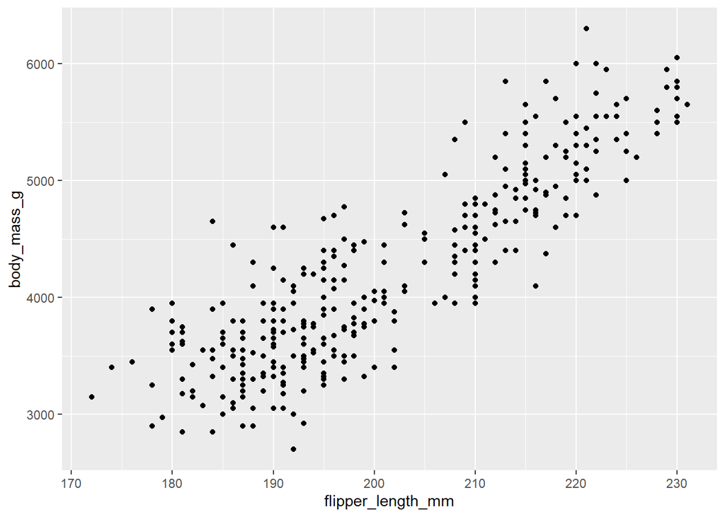

```r
# Gráfico de dispersión bidimensional básico # Aquí necesitamos especificar tanto el eje X como el eje Y
ggplot(penguins,aes(x = flipper_length_mm, y = body_mass_g)) +
  geom_point()
```

Este gráfico de dispersión muestra la relación entre la longitud de la aleta (eje X) y la masa corporal (eje Y) de los pingüinos. Podemos observar una tendencia positiva: en general, los pingüinos con aletas más largas tienden a tener mayor masa corporal.

Dentro de la función `aes()` podemos especificar cómo las variables del conjunto de datos se traducen en propiedades visuales del gráfico. Estas propiedades visuales se denominan *aesthetics* y permiten incorporar información adicional sin necesidad de crear gráficos separados.

En un **gráficos bidimensionales**, además de definir las variables que se representan en los ejes X e Y, es posible mapear otras variables del dataset a distintos atributos visuales, entre ellos:

- **color**: permite diferenciar grupos o categorías mediante colores distintos. Es especialmente útil para variables categóricas. Aunque también puede usarse con variables continuas.
- **shape**: asigna distintas formas a los puntos según una variable categórica.
- **size**: controla el tamaño de los puntos. Puede utilizarse para representar variables continuas o, con precaución, variables categóricas.
- **alpha (transparencia)**: permite ajustar la opacidad de los puntos. Aunque suele fijarse como un valor constante, también puede mapearse a una variable para resaltar gradientes o reducir problemas de solapamiento.

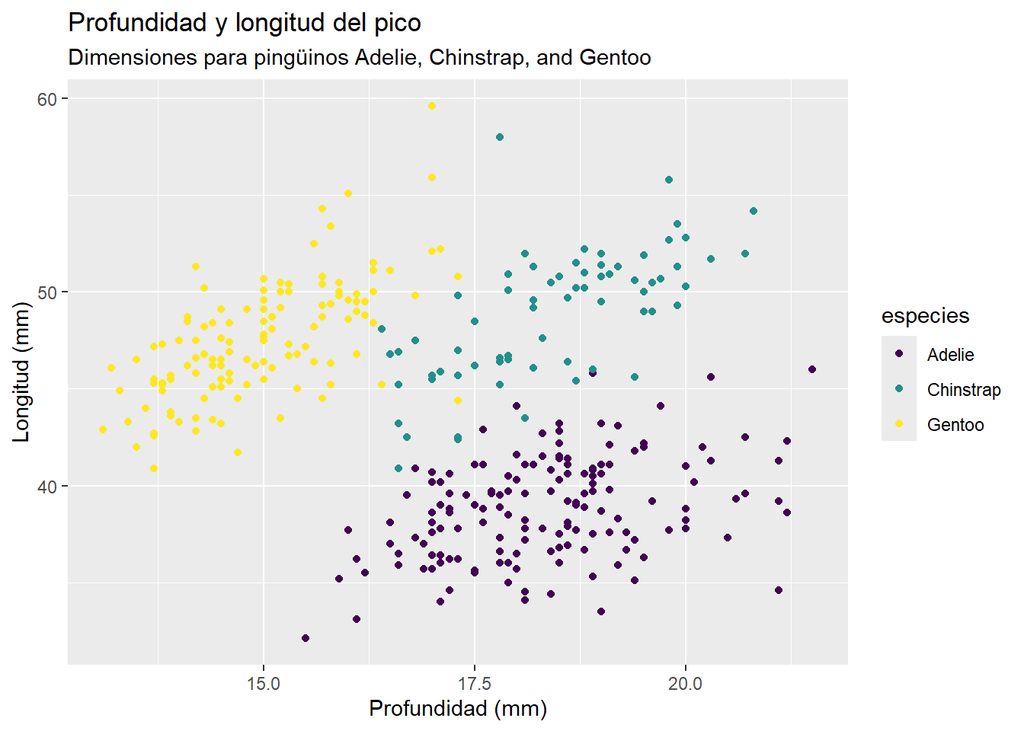

```r
ggplot(data = penguins, #llama al data.frame
       mapping = aes(x = bill_depth_mm, y = bill_length_mm, #x e y
                     colour = species)) + #pone las especies
  geom_point() +
  #hace un gráfico de dispersión de puntos
  labs(title = "Profundidad y longitud del pico",
       subtitle = "Dimensiones para pingüinos Adelie, Chinstrap, and Gentoo",
       x = "Profundidad (mm)", y = "Longitud (mm)",
       colour = "especies") +
  scale_colour_viridis_d() #pone escalas de color
```

**¿Qué tipo de relación hay entre la longitud y la produndidad del pico?**

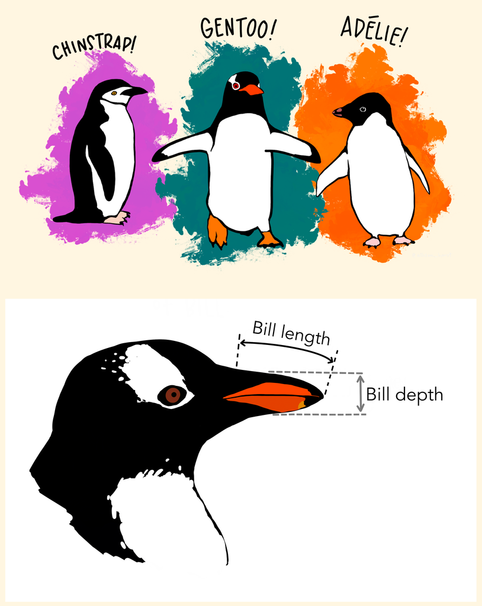

Dentro de **aesthetics** podemos determinar todas las caracteristicas específicas de una determinada variable como el color, la forma, el tamaño o la transparencia (`alpha`).

#### 1.3.0.2 📝 Ejercicio: Penguins, gráficos de dispersión

Si puedes haz un gráfico de dispersión, pero sin diferenciar colores para cada especie y guardalo en la carpeta de resutlados. Dentro de el argumento `aes()` prueba a poner el color azul con transparecnia, la forma de triangulo y que el tamaño dependa del peso del pinguino. Después prueba a hacer un segundo gráfico donde la forma o `shape` dependa de la isla a la que pertenece.

#### 1.3.0.3 **💡 Consejo: Usa la chuleta de ggplot2 para los ejercicios**

#### 1.3.0.4 📝 Ejercicio: calcula la corelación entre la profundidad y el largo del pico para cada especie.

Además de los gráficos de dispersión, se pueden hacer otro tipos de gráficos que muestran la relación entre dos variables:

[figure not shown]

```r
ggplot(penguins, aes(x = bill_depth_mm, y = bill_length_mm)) +
  geom_hex()
```

Además, podríamos ver la relación entre dos variables, por ejemplo, incluyendo una linea. Esta información está sacada de (aquí)[https://allisonhorst.github.io/palmerpenguins/articles/examples.html]

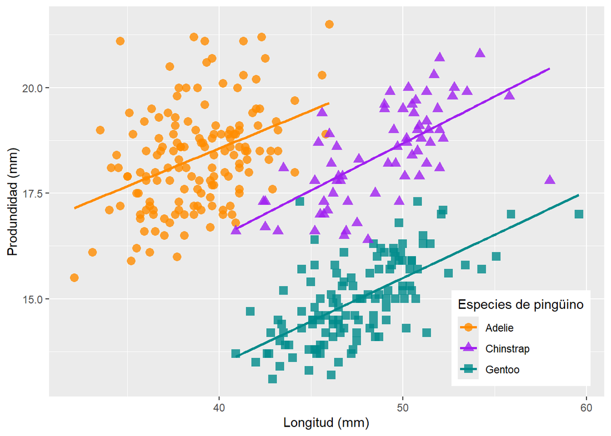

```r
bill_len_dep <- ggplot(data = penguins,
                         aes(x = bill_length_mm,
                             y = bill_depth_mm,
                             group = species)) +
  geom_point(aes(color = species,
                 shape = species),
             size = 3,
             alpha = 0.8) +
  geom_smooth(method = "lm", se = FALSE, aes(color = species)) +
  scale_color_manual(values = c("darkorange","purple","cyan4")) +
  labs(x = "Longitud (mm)",
       y = "Produndidad (mm)",
       color = "Especies de pingüino",
       shape = "Especies de pingüino") +
  theme(legend.position = c(0.85, 0.15),
        plot.title.position = "plot",
        plot.caption = element_text(hjust = 0, face= "italic"),
        plot.caption.position = "plot")

bill_len_dep
```

Además, si omitieramos la información a nivel de especie podríamos encontrarnos ante la paradoja de Simpson.

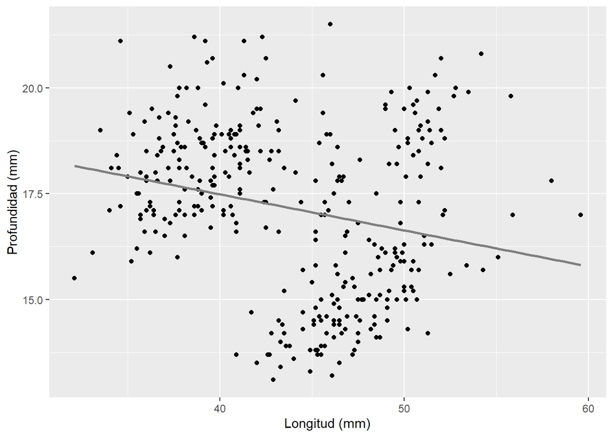

```r
bill_no_species <- ggplot(data = penguins,
                         aes(x = bill_length_mm,
                             y = bill_depth_mm)) +
  geom_point() +
  labs( x = "Longitud (mm)",
       y = "Profundidad (mm)") +
  theme(plot.title.position = "plot",
        plot.caption = element_text(hjust = 0, face= "italic"),
        plot.caption.position = "plot") +
  geom_smooth(method = "lm", se = FALSE, color = "gray50")

bill_no_species
```

#### 1.3.0.5 📝 Ejericio: Partiendo de la base de datos `penguins`, crea **un gráfico de dispersión (scatterplot)** que muestre la relación entre:

- **Longitud del pico** (`bill_length_mm`) en el eje X
- **Masa corporal** (`body_mass_g`) en el eje Y

En el gráfico, **deben incorporarse los siguientes aesthetics dentro de `aes()`**:

- **Color (`color`)**
  - Mapea la variable **`species`** para diferenciar las especies de pingüinos.
- **Forma (`shape`)**
  - Usa la variable **`sex`** para asignar distintas formas a los puntos.
- **Tamaño (`size`)**
  - Representa el **año de observación (`year`)** mediante el tamaño de los puntos.
- **Transparencia (`alpha`)**
  - Ajusta la transparencia de los puntos para mejorar la visualización en zonas con solapamiento.
- ¿Crees que es necesario añadir todos los `aesthetics` para una buena visualización o que por el contrario puede complicar la interpretación de ciertos gráficos?

Una vez que hemos creado un gráfico que cumple con nuestros objetivos, es importante guardarlo en un formato y calidad adecuados para su uso en informes, presentaciones o publicaciones. La función `ggsave()` permite exportar gráficos en diversos formatos (JPG, PNG, PDF, SVG, etc.) con control preciso sobre dimensiones y resolución.

Primero debejos asignar nuestro gráfico a un objeto:

```r
# Primero, asignamos el gráfico a un objeto
plot_pinguinos <- ggplot(penguins,
                         aes(x = flipper_length_mm,
                             y = body_mass_g)) +
  geom_point()
```

Ahora, utilizando la funcion `ggsave()`, y especificando las características con las que queremos guardar nuetro gráfico (formato, tamaño, unidades, dpi, etc), procedemos a guardar el resultado para poderlo utilizar fuera del entorno de R.

```r
# Guardar en formato JPG con alta resolución (300 dpi)

ggsave(filename = "penguins_scatter.jpg",
       plot = plot_pinguinos,
       width = 12, height = 9,
       units = "cm", dpi = 300)

# Guardar en formato PDF (vectorial, ideal para publicaciones)

ggsave(filename = "penguins_scatter.pdf",
       plot = plot_pinguinos,
       width = 12, height = 9,
       units = "cm")
```

💡 Consejo sobre dimensiones: a veces usamos especificaciones detalladas sobre el formato de los gráficos. Cuando no hay directrices específicas, es recomendable diseñar los gráficos pensando en un formato A4 (21 × 29.7 cm), asegurándose de que todos los elementos sean legibles cuando se reduzcan o amplíen a este tamaño.

#### 1.3.0.6 📝 Ejericio: Guardar gráficos

Partiendo del **gráfico creado en el ejercicio anterior**, realiza las siguientes tareas:

- Guardar el gráfico en un archivo externo asegurando que la **calidad visual**, las **dimensiones** y la **resolución** sean adecuadas para su uso en un **informe académico o una presentación.**

Instrucciones:

1. Utiliza la función **`ggsave()`** para exportar el gráfico.
2. Prueba **distintas combinaciones** de los siguientes argumentos:
   - `width` y `height`
   - `units` (`"in"`, `"cm"`)
   - `dpi`
   - `device` (por ejemplo `"jpg"`, `"png"`)
3. Guarda **al menos dos versiones** del mismo gráfico.